# Data Science for Public Policy

Stretch 02

Author

Zehui Li, Mujin Li

## 1. Set up

### load the packages

```r
library(mice) # for imputating missing value
library(dplyr)
library(here)
library(withr)
library(tidyverse)
library(lubridate)
library(tidymodels)
library(themis)
library(recipes)
library(parsnip)
library(ranger)
library(ggplot2)
library(vip)
library(patchwork)
library(readr)       # for importing data
```

### a. Data preparation and introduction

Predicting Childcare Costs in a County

The dataset we are utilizing is sourced from the [National Database of Childcare Prices (NDCP)](https://www.dol.gov/agencies/wb/topics/featured-childcare), which serves as a comprehensive federal repository of childcare pricing information at the county level. This dataset offers detailed insights into childcare costs, categorized by childcare provider type, children’s age groups, and various county characteristics. Covering the period from 2008 to 2018, it encompasses a wide range of socio-economic variables pertinent to counties across the United States. It’s worth noting that the initial data cleaning and acquisition processes were conducted as part of the Tidy Tuesday project, and you can find further details about the dataset [here](https://github.com/rfordatascience/tidytuesday/blob/master/data/2023/2023-05-09/readme.md).

The objective of this regression application is to build a predictive model that can estimate the median weekly cost of Center-Based Care for school-age children in a county based on various socio-economic and demographic features of that county. The outcome variable for this regression application is the median weekly cost of Center-Based Care for school-age children (`mcsa`). Center-Based Care refers to childcare provided in a daycare center or facility. our predictor variables include:`unr_16`: Unemployment rate of the population aged 16 years old or older.`pr_f`: Poverty rate for families.`mhi_2018`: Median household income expressed in 2018 dollars.`total_pop`: Count of the total population etc.

```r
# All packages used in this script:
library(tidyverse)
library(here)
library(withr)

url <- "https://www.dol.gov/sites/dolgov/files/WB/media/nationaldatabaseofchildcareprices.xlsx"
temp_xlsx <- withr::local_tempfile(fileext = ".xlsx")
download.file(url, temp_xlsx, mode = "wb")

childcare_costs_raw <- readxl::read_xlsx(temp_xlsx) |>
  janitor::clean_names() |>
  # There are 15 constant columns. Get rid of those.
  janitor::remove_constant(quiet = FALSE)

# The file is very large, but it contains a lot of duplicate data. Extract
# duplications into their own tables.
counties <- childcare_costs_raw |>
  dplyr::distinct(county_fips_code, county_name, state_name, state_abbreviation)
childcare_costs <- childcare_costs_raw |>
  dplyr::select(
    -county_name,
    -state_name,
    -state_abbreviation,
    # Original data also contained unadjusted + adjusted dollars, let's just
    # keep the 2018 adjustments.
    -mhi, -me, -fme, -mme,
    # A number of columns have fine-grained breakdowns by age, and then also
    # broader categories. Let's only keep the categories ("infant" vs 0-5
    # months, 6-11 monts, etc)
    -ends_with("bto5"), -ends_with("6to11"), -ends_with("12to17"),
    -ends_with("18to23"), -ends_with("24to29"), -ends_with("30to35"),
    -ends_with("36to41"), -ends_with("42to47"), -ends_with("48to53"),
    -ends_with("54to_sa"),
    # Since we aren't worrying about the unaggregated columns, we can ignore the
    # flags indicating how those columns were aggregated into the combined
    # columns.
    -ends_with("_flag"),
    # Original data has both median and 75th percentile for a number of columns.
    # We'll simplify.
    -starts_with("x75"),
    # While important for wider research, we don't need to keep the (many)
    # variables describing whether certain data was imputed.
    -starts_with("i_")
  )
```

### b.Split the data into training and testing data

```r
childcare_costs
```

```
# A tibble: 34,567 × 61
   county_fips_code study_year unr_16 funr_16 munr_16 unr_20to64 funr_20to64
              <dbl>      <dbl>  <dbl>   <dbl>   <dbl>      <dbl>       <dbl>
 1             1001       2008   5.42    4.41    6.32        4.6         3.5
 2             1001       2009   5.93    5.72    6.11        4.8         4.6
 3             1001       2010   6.21    5.57    6.78        5.1         4.6
 4             1001       2011   7.55    8.13    7.03        6.2         6.3
 5             1001       2012   8.6     8.88    8.29        6.7         6.4
 6             1001       2013   9.39   10.3     8.56        7.3         7.6
 7             1001       2014   8.5     9.18    7.95        6.8         6.8
 8             1001       2015   7.64    8.45    6.91        5.9         6.1
 9             1001       2016   5.59    6.27    4.99        4.4         4.6
10             1001       2017   5.21    5.84    4.64        4.6         4.9
# ℹ 34,557 more rows
# ℹ 54 more variables: munr_20to64 <dbl>, flfpr_20to64 <dbl>,
#   flfpr_20to64_under6 <dbl>, flfpr_20to64_6to17 <dbl>,
#   flfpr_20to64_under6_6to17 <dbl>, mlfpr_20to64 <dbl>, pr_f <dbl>,
#   pr_p <dbl>, mhi_2018 <dbl>, me_2018 <dbl>, fme_2018 <dbl>, mme_2018 <dbl>,
#   total_pop <dbl>, one_race <dbl>, one_race_w <dbl>, one_race_b <dbl>,
#   one_race_i <dbl>, one_race_a <dbl>, one_race_h <dbl>, …
```

```r
# select mcsa as my outcome
childcare_costs<- subset(childcare_costs, select = -c(mfccsa, mc_infant, mc_toddler, mc_preschool, mfcc_infant, mfcc_toddler, mfcc_preschool))
# missing value test
childcare_costs%>%
  group_by(county_fips_code)%>%
  summarise(missing_values = sum(is.na(mcsa)))
```

```
# A tibble: 3,144 × 2
   county_fips_code missing_values
              <dbl>          <int>
 1             1001              0
 2             1003              0
 3             1005              0
 4             1007              0
 5             1009              0
 6             1011              0
 7             1013              0
 8             1015              0
 9             1017              0
10             1019              0
# ℹ 3,134 more rows
```

```r
# use mean value to fill missing value
childcare_costs$h_under6_single_m <- ifelse(is.na(childcare_costs$h_under6_single_m), mean(childcare_costs$h_under6_single_m, na.rm = TRUE), childcare_costs$h_under6_single_m)
childcare_costs$h_6to17_single_m <- ifelse(is.na(childcare_costs$h_6to17_single_m), mean(childcare_costs$h_6to17_single_m, na.rm = TRUE), childcare_costs$h_6to17_single_m)
# pick out the rows includes the missing value
implement <- childcare_costs[is.na(childcare_costs$mcsa), ]
childcare_modeling <- childcare_costs[complete.cases(childcare_costs), ]
# examine the missing value
childcare_modeling %>%
  summarise_all(~ sum(is.na(.)))
```

```
# A tibble: 1 × 54
  county_fips_code study_year unr_16 funr_16 munr_16 unr_20to64 funr_20to64
             <int>      <int>  <int>   <int>   <int>      <int>       <int>
1                0          0      0       0       0          0           0
# ℹ 47 more variables: munr_20to64 <int>, flfpr_20to64 <int>,
#   flfpr_20to64_under6 <int>, flfpr_20to64_6to17 <int>,
#   flfpr_20to64_under6_6to17 <int>, mlfpr_20to64 <int>, pr_f <int>,
#   pr_p <int>, mhi_2018 <int>, me_2018 <int>, fme_2018 <int>, mme_2018 <int>,
#   total_pop <int>, one_race <int>, one_race_w <int>, one_race_b <int>,
#   one_race_i <int>, one_race_a <int>, one_race_h <int>, one_race_other <int>,
#   two_races <int>, hispanic <int>, households <int>, …
```

```r
glimpse(childcare_costs$mcsa)
```

```
 num [1:34567] 80.9 83.4 85.9 88.4 90.9 ...
```

```r
# select the column with large value
needtolog <- childcare_modeling %>%
  select(starts_with("h")) %>%
  names()
needtolog <- needtolog[needtolog != "hispanic"]
needtolog <- c(needtolog, "total_pop")
```

#### split data into train and test

```r
set.seed(701)
split <-initial_split(childcare_modeling,strata = c("county_fips_code"))
train<-training(split)
test<-testing(split)
```

### c.Explortary data analysis

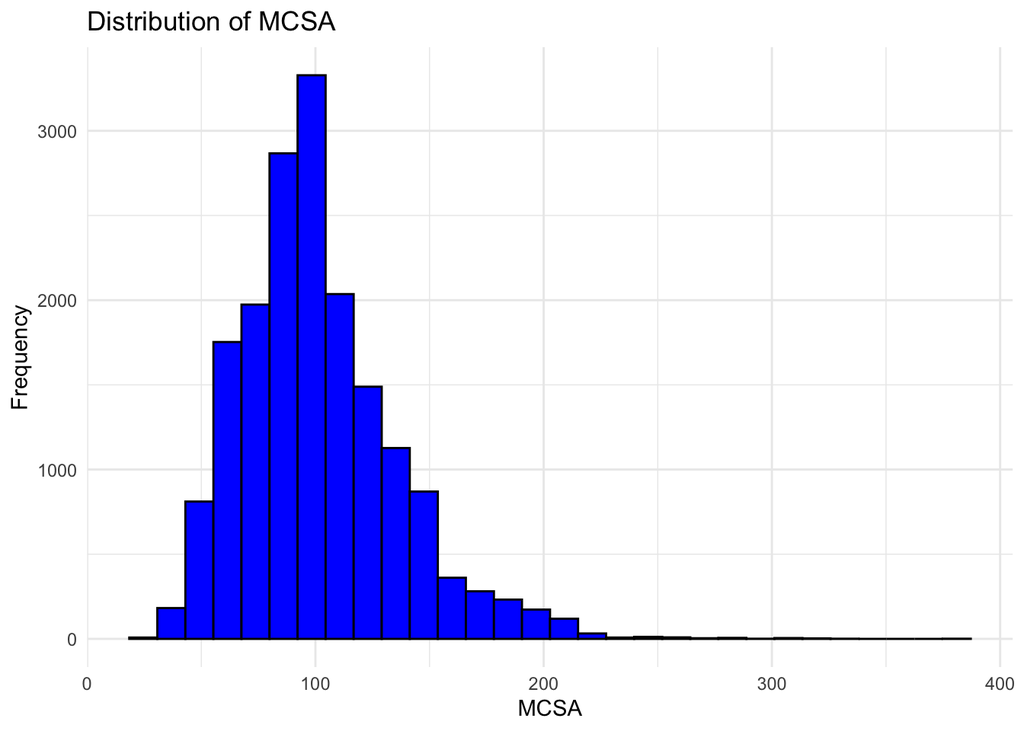

```r
#Distribution about mcsa
ggplot(data = train, aes(x = mcsa)) +
  geom_histogram(fill = "blue", color = "black", bins = 30) +
  labs(title = "Distribution of MCSA",
       x = "MCSA",
       y = "Frequency")+
  theme_minimal()
```

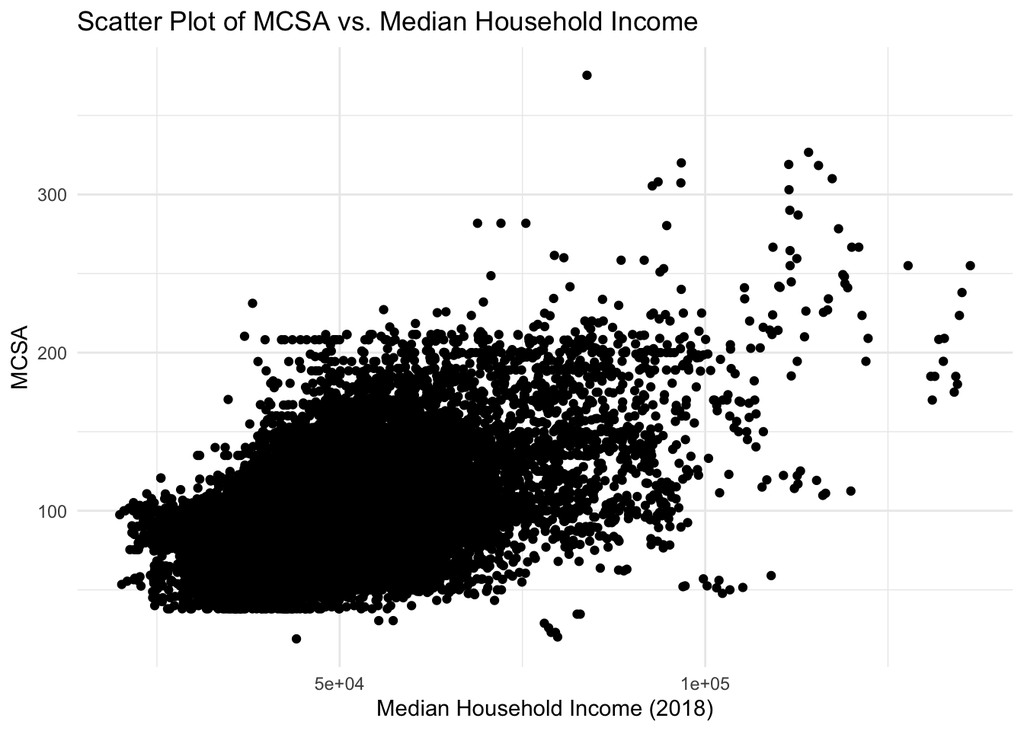

```r
# Scatter Plot of MCSA vs. Median Household Income
ggplot(data = train, aes(x = mhi_2018, y = mcsa)) +
  geom_point() +
  labs(title = "Scatter Plot of MCSA vs. Median Household Income",
       x = "Median Household Income (2018)",
       y = "MCSA")+
  theme_minimal()
```

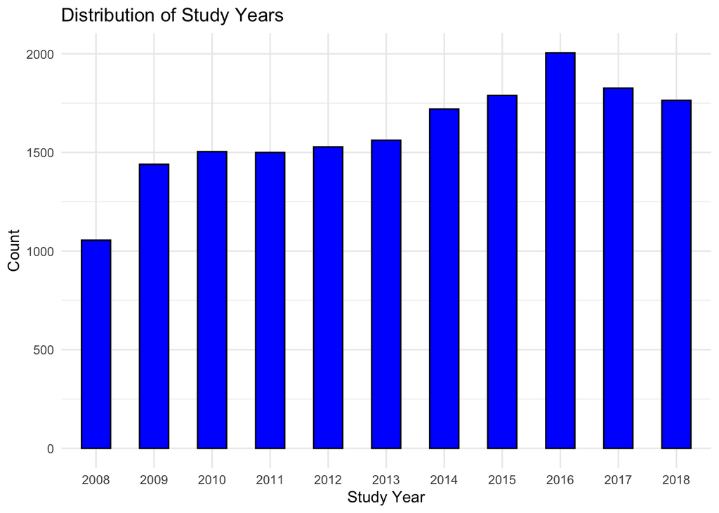

```r
# Bar chart for 'study_year'
ggplot(data = train, aes(x = factor(study_year))) +
  geom_bar(fill = "blue", color = "black",width = 0.5) +
  labs(title = "Distribution of Study Years",
       x = "Study Year",
       y = "Count")+
  theme_minimal()
```

### d.Error Metric

RMSE, which stands for Root Mean Square Error, is a commonly used metric in regression analysis to quantify the average magnitude of errors between predicted values and actual observed values. It measures the square root of the average of the squared differences between predicted and observed values. Larger errors, as indicated by RMSE, generally incur higher costs. “mcsa” relates to childcare costs, larger prediction errors might affect budget planning or subsidy allocation.There is no universal threshold for RMSE, and it should be determined according to the application’s requirements and acceptable level of prediction accuracy. Generally, a lower RMSE values indicating better model performance. Since we are dealing with a regression problem, the concepts of false positives and false negatives are more relevant in classification tasks. MSE:
$$MSE = \frac{1}{n} \sum_{i=1}^{n} (y_i - \hat{y}_i)^2$$
RMSE:
$$RMSE = \sqrt{MSE}$$
MAE:
$$MAE = \frac{1}{n} \sum_{i=1}^{n} |y_i - \hat{y}_i|$$

#### set resample

```r
set.seed(234)
folds<-vfold_cv(train, v = 10)
```

## 2&3 come up with models

### create recipe

```r
recipe<-recipe(mcsa~.,data = train)%>%
  step_dummy(all_nominal_predictors())%>%
  step_zv(all_predictors()) %>%
  step_impute_knn(all_predictors())%>%
  step_scale(all_numeric_predictors())
bake(prep(recipe, training = train),new_data = train)
```

```
# A tibble: 17,693 × 54
   county_fips_code study_year unr_16 funr_16 munr_16 unr_20to64 funr_20to64
              <dbl>      <dbl>  <dbl>   <dbl>   <dbl>      <dbl>       <dbl>
 1           0.0644       652.   1.53   1.23     1.56       1.33       1.00
 2           0.0644       653.   1.75   1.56     1.68       1.48       1.32
 3           0.0644       654.   2.42   2.49     2.05       1.94       1.84
 4           0.0644       654.   2.39   2.57     1.96       1.97       1.95
 5           0.0644       655.   2.15   2.36     1.71       1.71       1.75
 6           0.0644       655.   1.57   1.75     1.23       1.27       1.32
 7           0.0644       656.   1.19   0.954    1.22       1.13       0.861
 8           0.0645       652.   1.19   1.06     1.14       1.10       1.00
 9           0.0645       653.   1.56   1.52     1.40       1.39       1.41
10           0.0645       653.   1.85   1.79     1.66       1.71       1.61
# ℹ 17,683 more rows
# ℹ 47 more variables: munr_20to64 <dbl>, flfpr_20to64 <dbl>,
#   flfpr_20to64_under6 <dbl>, flfpr_20to64_6to17 <dbl>,
#   flfpr_20to64_under6_6to17 <dbl>, mlfpr_20to64 <dbl>, pr_f <dbl>,
#   pr_p <dbl>, mhi_2018 <dbl>, me_2018 <dbl>, fme_2018 <dbl>, mme_2018 <dbl>,
#   total_pop <dbl>, one_race <dbl>, one_race_w <dbl>, one_race_b <dbl>,
#   one_race_i <dbl>, one_race_a <dbl>, one_race_h <dbl>, …
```

```r
train%>%
  summarise_all(~ sum(is.na(.)))
```

```
# A tibble: 1 × 54
  county_fips_code study_year unr_16 funr_16 munr_16 unr_20to64 funr_20to64
             <int>      <int>  <int>   <int>   <int>      <int>       <int>
1                0          0      0       0       0          0           0
# ℹ 47 more variables: munr_20to64 <int>, flfpr_20to64 <int>,
#   flfpr_20to64_under6 <int>, flfpr_20to64_6to17 <int>,
#   flfpr_20to64_under6_6to17 <int>, mlfpr_20to64 <int>, pr_f <int>,
#   pr_p <int>, mhi_2018 <int>, me_2018 <int>, fme_2018 <int>, mme_2018 <int>,
#   total_pop <int>, one_race <int>, one_race_w <int>, one_race_b <int>,
#   one_race_i <int>, one_race_a <int>, one_race_h <int>, one_race_other <int>,
#   two_races <int>, hispanic <int>, households <int>, …
```

### penalized lasso regression

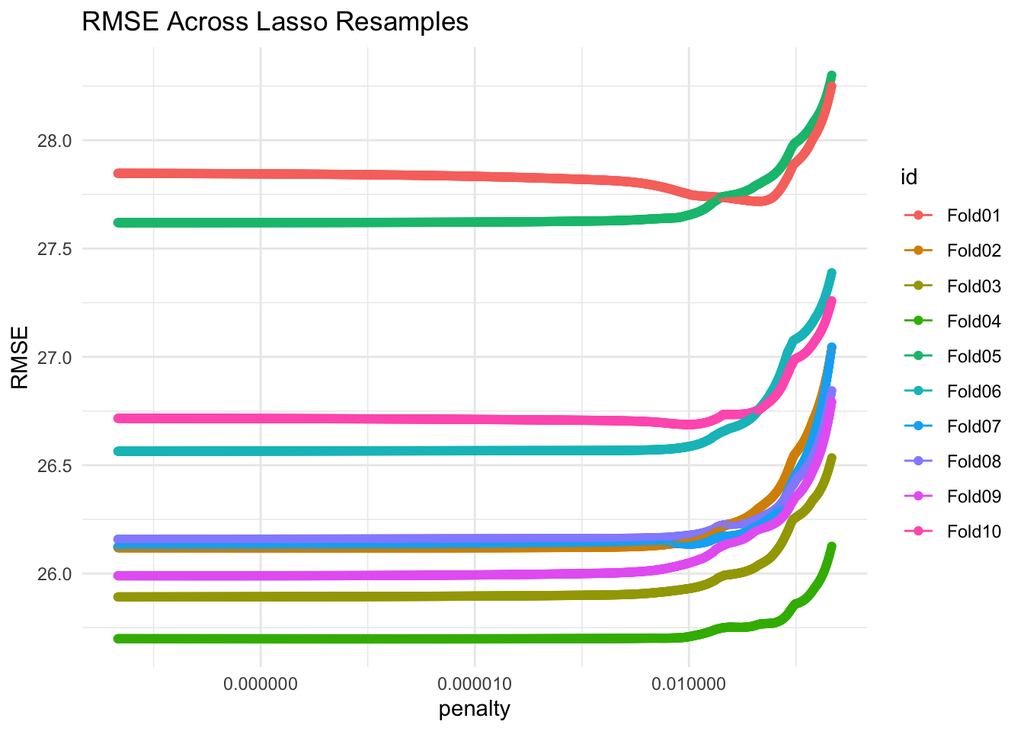

```r
# use Cross-Validation
lasso_grid <- grid_regular(penalty(), levels = 1000)
lasso_mod <- linear_reg(
  penalty = tune(),
  mixture = 1
) %>%
  set_engine("glmnet", path_values = lasso_grid$penalty)
#create the workflow
lasso_wf<-
  workflow()%>%
  add_model(lasso_mod)%>%
  add_recipe(recipe)
#train and tune the model
lasso_res <-
  lasso_wf %>%
  tune_grid(folds,#use resample
            grid = lasso_grid,
            control = control_grid(save_pred = TRUE),
            metrics = metric_set(rmse))
# plot the visulization of penalty and rmse
lasso_rmse<-
  collect_metrics(lasso_res, summarize = FALSE) %>%
  filter(.metric == "rmse")

lasso_plot <-ggplot(lasso_rmse, aes(x = penalty, y = .estimate,color = id)) +
  geom_line() +
  geom_point() +
  scale_x_log10(labels = scales::label_number())+
  labs(title = "RMSE Across Lasso Resamples",
       x = "penalty",
       y = "RMSE") +
  theme_minimal()

lasso_plot
```

### the last fit & visualize the variable importance scores for the top 20 features

```r
# the last model
lasso_best<-lasso_res%>%
  select_best(metric = "rmse")
lasso_best
```

```
# A tibble: 1 × 2
      penalty .config
        <dbl> <chr>
1 0.000000964 Preprocessor1_Model0399
```

```r
best_lasso_mod <-
  linear_reg(penalty = lasso_best$penalty, mixture = 1) %>%
  set_engine("glmnet",importance = "impurity")

# the last workflow
best_lasso_wf <-
  lasso_wf %>%
  update_model(best_lasso_mod)

# the last fit
set.seed(701)
best_lasso_fit <- best_lasso_wf %>%
  last_fit(split)

best_lasso_fit
```

```
# Resampling results
# Manual resampling
# A tibble: 1 × 6
  splits               id              .metrics .notes   .predictions .workflow
  <list>               <chr>           <list>   <list>   <list>       <list>
1 <split [17693/5900]> train/test spl… <tibble> <tibble> <tibble>     <workflow>
```

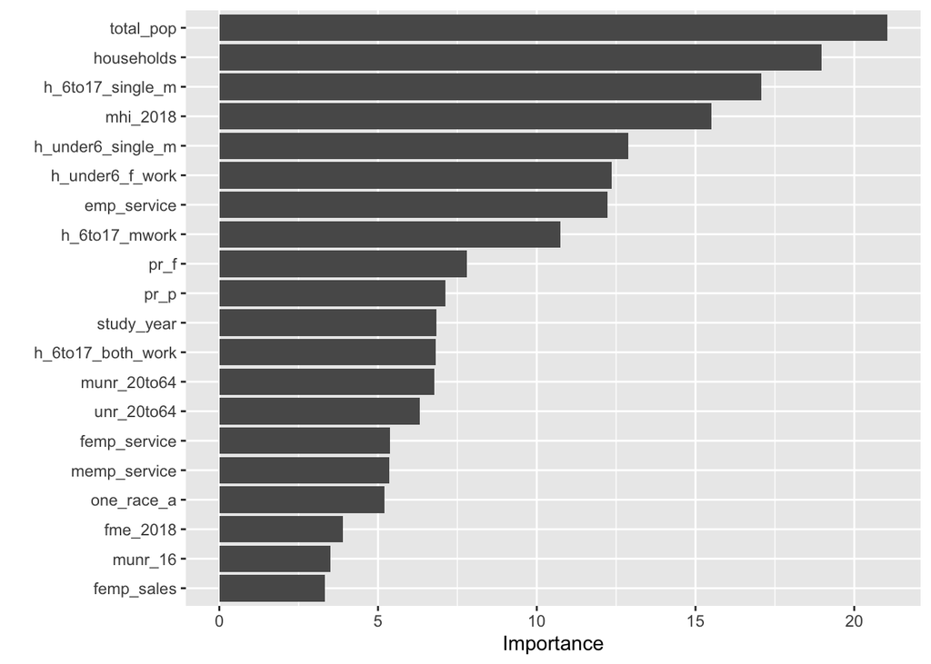

```r
best_lasso_fit %>%
  extract_fit_parsnip() %>%
  vip(num_features = 20)
```

### random forest

```r
#use the parallel package to query the number of cores on my computer
cores <- parallel::detectCores()
cores
```

```
[1] 10
```

```r
#build the model
rf_mod <-
  rand_forest(mtry = tune(), min_n = tune(), trees = 1000) %>%
  set_engine("ranger",num.threads = 10) %>%
  set_mode("regression")
#create the workflow
rf_wf <-
  workflow() %>%
  add_model(rf_mod) %>%
  add_recipe(recipe)
# train and tune the model
set.seed(345)
rf_res <-
  rf_wf %>%
  tune_grid(folds,
            grid = 5,
            control = control_grid(save_pred = TRUE),
            metrics = metric_set(rmse))
# find the best mtry&min_n value
rf_res %>%
  show_best(metric = "rmse")
```

```
# A tibble: 5 × 8
   mtry min_n .metric .estimator  mean     n std_err .config
  <int> <int> <chr>   <chr>      <dbl> <int>   <dbl> <chr>
1    32     6 rmse    standard    11.5    10   0.142 Preprocessor1_Model1
2    35    26 rmse    standard    12.2    10   0.150 Preprocessor1_Model5
3    49    36 rmse    standard    12.3    10   0.140 Preprocessor1_Model3
4    13    17 rmse    standard    14.3    10   0.177 Preprocessor1_Model4
5     1    20 rmse    standard    21.7    10   0.209 Preprocessor1_Model2
```

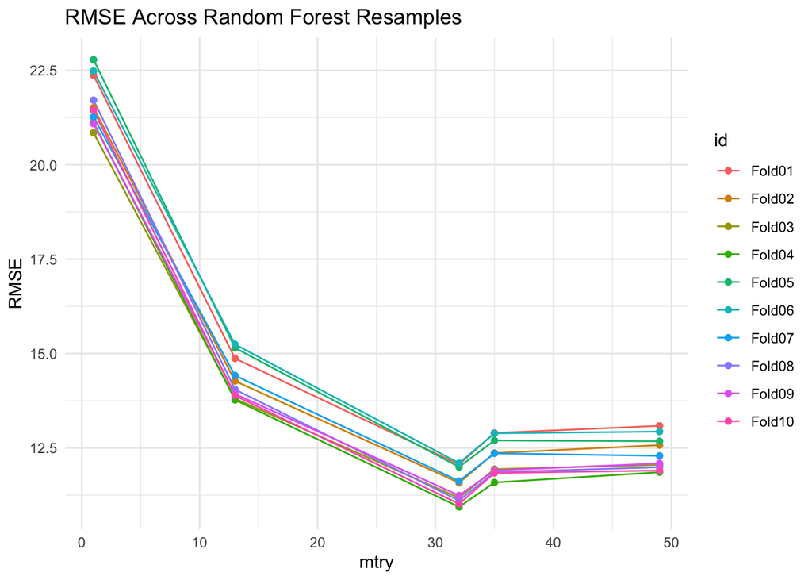

```r
# plot the visulization of mtry and rmse
rf_rmse<-
  collect_metrics(rf_res, summarize = FALSE) %>%
  filter(.metric == "rmse")

rf_plot <-ggplot(rf_rmse, aes(x = mtry, y = .estimate,color = id)) +
  geom_line() +
  geom_point() +
  labs(title = "RMSE Across Random Forest Resamples",
       x = "mtry",
       y = "RMSE") +
  theme_minimal()

rf_plot
```

### Estimate the out-of-sample error rate

```r
#select my best random forest model
rf_best<-rf_res%>%
  select_best(metric = "rmse")
rf_best
```

```
# A tibble: 1 × 3
   mtry min_n .config
  <int> <int> <chr>
1    32     6 Preprocessor1_Model1
```

```r
# use best model make predictions with test dataset
rf_best_test <- finalize_workflow(
  rf_wf,
  parameters = rf_best
)
rf_best_test_fit<-rf_best_test%>%
  fit(data = train) # use original train dataset
test_prediction <- rf_best_test_fit%>%
  predict(new_data = test) #use test dataset

rmse_test <- bind_cols(test %>% select(mcsa),
                       test_prediction %>% select(.pred)
                       )%>% #combine the true value from test dataset and the predicted value
  rmse(truth = mcsa, estimate = .pred)
rmse_test
```

```
# A tibble: 1 × 3
  .metric .estimator .estimate
  <chr>   <chr>          <dbl>
1 rmse    standard        11.6
```